# Homework 5

Categorical data(=not represented by numbers) VS Numerical data (=represented by numbers)

t-test is for comparing the difference between two means

f-test is comparing the difference between many means

`Let's work with the norm experiment data some more.`

```r
library(tidyverse)
library(dplyr)
library(readxl)
library(descr)
library(infer)
```

**QUESTION 1**

`1. Formally test a hypothesis that any normative message is significantly different from any empirical message in its effects on cheating.`

```r
library(readxl)
exp21 <- read_excel("experiment_2021C(1)copy.xlsx", col_names = FALSE,
    skip = 2)
```

```
* `` -> ...1
* `` -> ...2
* `` -> ...3
* `` -> ...4
* `` -> ...5
* ...
```

```r
View(exp21)
```

`a) state the research hypothesis`

`b) state the null hypothesis`

**H0**: I **assume** that the mean of the people who were in the normative message is **no different** from the mean of the people with empirical message.

**H1**: I **assume** that the outcome mean of the people with normative message is **different** from the mean of the people with empirical message.

`c) state the test used and describe the procedure (what will be your procedure to decide on the answer to your question)`

We currently only have descriptive statistics. This means that while our statistics tell us about the results we have right now, they don’t reveal us the chances of those results re-occurring.

Just looking at the means would not ensure that they are reliable. Therefore we need to conduct a t-test (inferential statistic) for that. In other words, the t-test would allow us to generalize our results to a whole population beyond the sample we are testing. In our case, the t-test will help us identify if the difference between the means is real or if it occurs by chance.

I take the dataset from the previous exercise and I name it “attempt1”. This is for purposes of ease. In other words it is to remember the messages used to the experiment with their corresponding numbers, as well as the new columns created in the previous exercise; ‘id’ and ‘rolnum’.

```r
attempt1 <- exp21 %>%
             mutate(condition = case_when(Control_Msg != "" ~ 1,
                                   Norm_Pos_Msg != "" ~ 2,
                                   Norm_Neg_Msg != "" ~ 3,
                                   Emp_Neg_Msg != "" ~ 4,
                                   Emp_Pos_Msg != "" ~ 5),
                    id = 1:133,
                    rolnum = 1:133)
```

[output not shown]

I use this to remove the condition that is equal to 1 (=control message) from the table so I can be left only with normative and empirical message.

```
   Cell Contents
|-------------------------|
|                   Count |
|         Expected Values |
|-------------------------|

====================================================
                     attempt5$condition
attempt5$cheating      2      3      4     5   Total
----------------------------------------------------
No                     6     40     31     9      86
                     9.6   39.0   28.7   8.8
----------------------------------------------------
Yes                    6      9      5     2      22
                     2.4   10.0    7.3   2.2
----------------------------------------------------
Total                 12     49     36    11     108
====================================================
```

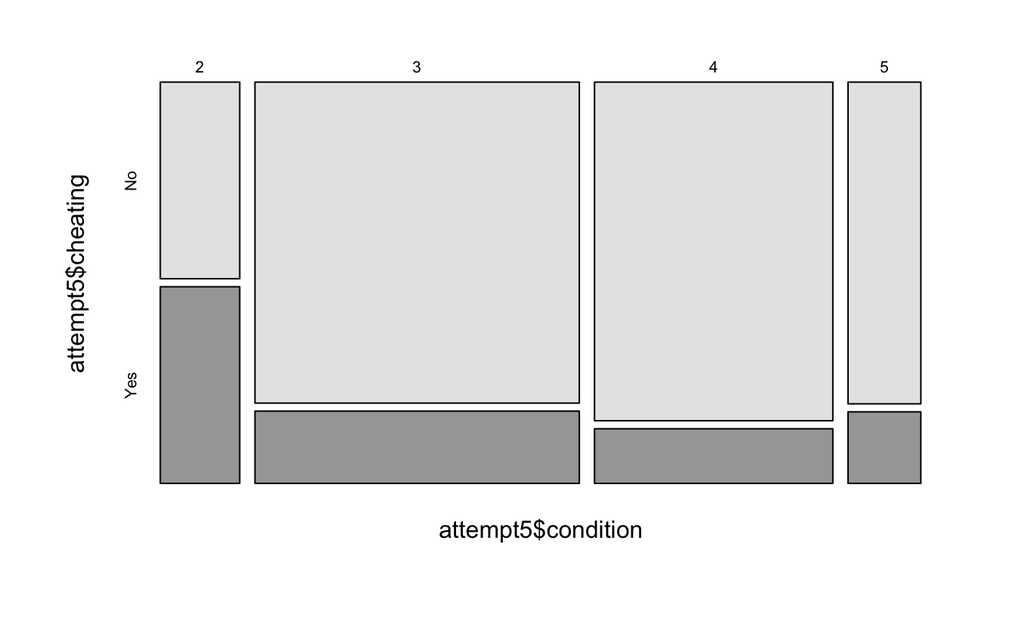

```r
crosstab(attempt5$cheating, attempt5$condition, expected = TRUE)
```

```
   Cell Contents
|-------------------------|
|                   Count |
|         Expected Values |
|-------------------------|

====================================
                     onlynorm$condition
onlynorm$cheating     2    3   Total
------------------------------------
No                    6   40      46
                      9   37
------------------------------------
Yes                   6    9      15
                      3   12
------------------------------------
Total                12   49      61
====================================
```

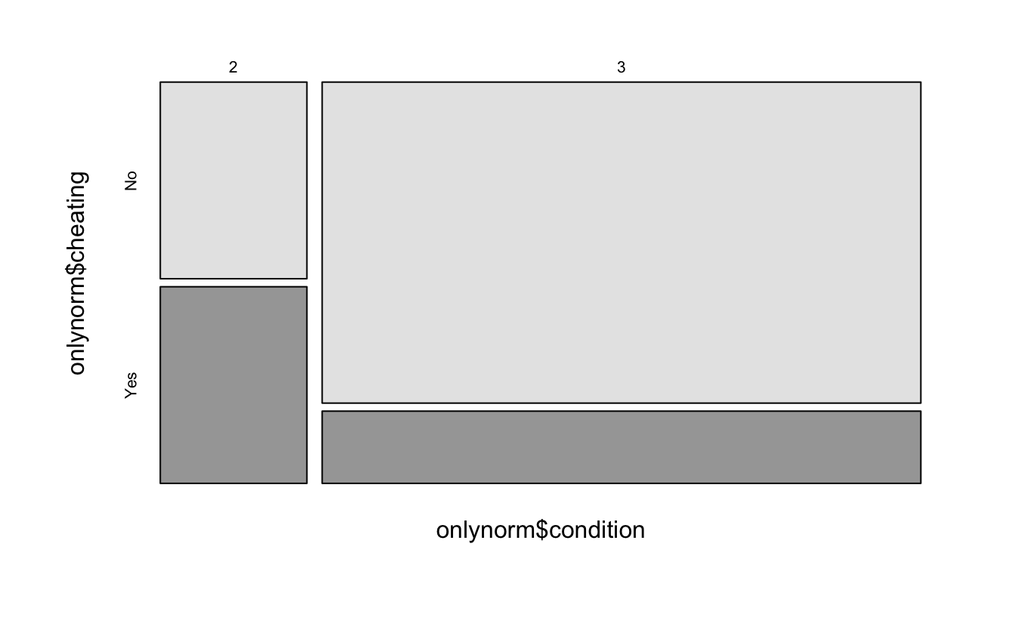

```r
crosstab(onlynorm$cheating, onlynorm$condition, expected = TRUE)
```

```
   Cell Contents
|-------------------------|
|                   Count |
|         Expected Values |
|-------------------------|

=======================================
                     onlyempi$condition
onlyempi$cheating       4     5   Total
---------------------------------------
No                     31     9      40
                     30.6   9.4
---------------------------------------
Yes                     5     2       7
                      5.4   1.6
---------------------------------------
Total                  36    11      47
=======================================
```

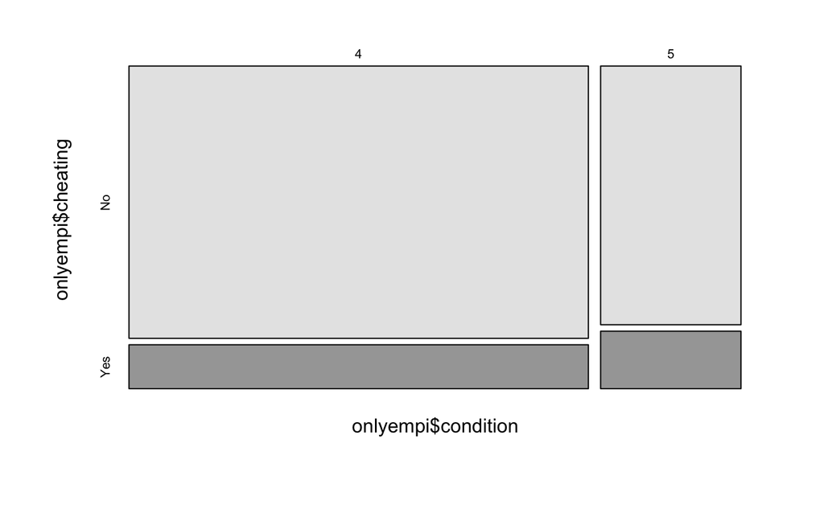

```r
crosstab(onlyempi$cheating, onlyempi$condition, expected = TRUE)
```

Here, I use the cleaned dataset of the previous exercise which contains all the final information and I name it “attempt2”. This helps for the next step.